# Titanic Class-Survival Analysis: Mechanisms, Context, and Data Quality

Author

CLI Copilot

## Introduction and Research Framework

This analysis examines three interconnected research questions about the Titanic disaster that go beyond simple survival statistics to investigate the mechanisms and inequalities underlying the survival gap across passenger classes. The analysis operates within the constraint of available Kaggle Titanic data fields and uses carefully constructed proxies and methodological approaches to operationalize conceptual constructs.

The research questions are:

1. **Class and Access**: To what extent is the survival advantage of 1st class passengers explained by location/access factors (cabin location, fare, embarkation) versus explicit priority policies (“women and children first”)?
2. **Social Visibility and Group Context**: Did survival rules operate uniformly, or did their effectiveness depend on social visibility (indicated by fare, passenger title) and whether passengers traveled alone versus with family/groups?
3. **Missing Data as a Structural Signal**: Are patterns of missingness (particularly in Cabin and Age) systematically related to class and survival, and how do different missing-data assumptions affect conclusions?

Each section below details the operational strategy, code implementation, and interpretive logic.

## Section 1: Data Overview and Preliminary Assessment

### Loading and Exploring the Dataset

```r
library(tidyverse)
library(knitr)
library(scales)
library(RColorBrewer)
library(kableExtra)

# Load training data
train <- read_csv("/Users/patrickl/Developer/Personal-Repo/cli_poc_ml_project/data/train.csv")

# Display basic structure and dimensions
dim(train)
```

```
[1] 891  12
```

```r
# Check data types and missing values
summary(train)
```

```
  PassengerId       Survived          Pclass          Name
 Min.   :  1.0   Min.   :0.0000   Min.   :1.000   Length:891
 1st Qu.:223.5   1st Qu.:0.0000   1st Qu.:2.000   Class :character
 Median :446.0   Median :0.0000   Median :3.000   Mode  :character
 Mean   :446.0   Mean   :0.3838   Mean   :2.309
 3rd Qu.:668.5   3rd Qu.:1.0000   3rd Qu.:3.000
 Max.   :891.0   Max.   :1.0000   Max.   :3.000

     Sex                 Age            SibSp           Parch
 Length:891         Min.   : 0.42   Min.   :0.000   Min.   :0.0000
 Class :character   1st Qu.:20.12   1st Qu.:0.000   1st Qu.:0.0000
 Mode  :character   Median :28.00   Median :0.000   Median :0.0000
                    Mean   :29.70   Mean   :0.523   Mean   :0.3816
                    3rd Qu.:38.00   3rd Qu.:1.000   3rd Qu.:0.0000
                    Max.   :80.00   Max.   :8.000   Max.   :6.0000
                    NA's   :177
    Ticket               Fare           Cabin             Embarked
 Length:891         Min.   :  0.00   Length:891         Length:891
 Class :character   1st Qu.:  7.91   Class :character   Class :character
 Mode  :character   Median : 14.45   Mode  :character   Mode  :character
                    Mean   : 32.20
                    3rd Qu.: 31.00
                    Max.   :512.33
```

```r
# Overall survival rates by class
class_survival <- train %>%
  group_by(Pclass) %>%
  summarize(
    n_passengers = n(),
    n_survived = sum(Survived, na.rm = TRUE),
    survival_rate = mean(Survived, na.rm = TRUE),
    .groups = "drop"
  )

kable(class_survival, digits = 3,
      caption = "Survival Rates by Passenger Class",
      col.names = c("Class", "Total Passengers", "Survived", "Survival Rate"))
```

Survival Rates by Passenger Class

| Class | Total Passengers | Survived | Survival Rate |
| --- | --- | --- | --- |
| 1 | 216 | 136 | 0.630 |
| 2 | 184 | 87 | 0.473 |
| 3 | 491 | 119 | 0.242 |

The baseline class-survival gap is dramatic: 1st class passengers had a survival rate of 63.0%, compared to 47.3% for 2nd class and 24.2% for 3rd class. This large differential serves as the empirical foundation for investigating mechanisms. Our strategy will be to operationalize candidate mechanisms and assess how much of this gap they explain.

## Section 2: Research Question 1 – Class Effects via Access vs. Priority Rules

### Conceptual Framework and Operationalization

The first research question asks: *Is the class survival advantage mediated by structural access (location, resources, information) rather than behavioral rules (women/children first)?* If class mattered primarily through access, controlling for proxies of access should attenuate the class effect. If priority rules were the dominant driver, controlling for those rules should have the largest effect.

We operationalize this distinction as follows:

- **Priority rules mechanism**: Measured by sex (male/female) and age. The principle “women and children first” is a rule applied to individuals within a class.
- **Access mechanisms**: Measured by fare (income/resources), cabin information (location and physical proximity to lifeboats), embarkation port (routing/boarding experience), and ticket group structure (coordination and visibility).

### Step 1: Extract and Construct Access Proxies

```r
# Create cabin-related features
train_analysis <- train %>%
  mutate(
    # Cabin missingness as a proxy for records or location knowledge
    cabin_missing = is.na(Cabin),
    # Extract cabin letter if present (deck indicator)
    cabin_letter = str_extract(Cabin, "^[A-Z]"),
    # Fare categories as proxy for access tier
    fare_category = case_when(
      Fare == 0 ~ "Free",
      Fare > 0 & Fare < 50 ~ "Low",
      Fare >= 50 & Fare < 150 ~ "Mid",
      Fare >= 150 ~ "High",
      is.na(Fare) ~ "Missing"
    ),
    # Group size from sibsp and parch
    family_size = SibSp + Parch,
    traveling_alone = family_size == 0,
    large_group = family_size >= 3
  )

# Check cabin letter distribution
cabin_dist <- train_analysis %>%
  filter(!is.na(cabin_letter)) %>%
  count(cabin_letter) %>%
  arrange(desc(n))

kable(cabin_dist, caption = "Distribution of Cabin Letters (Decks) Among Records with Cabin Information",
      col.names = c("Cabin Letter (Deck)", "Count"))
```

Distribution of Cabin Letters (Decks) Among Records with Cabin Information

| Cabin Letter (Deck) | Count |
| --- | --- |
| C | 59 |
| B | 47 |
| D | 33 |
| E | 32 |
| A | 15 |
| F | 13 |
| G | 4 |
| T | 1 |

We extract cabin deck information where available—passengers with known cabin assignments are by definition more documented and likely had better access (proximity to lifeboats, crew communication). Of the 204 passengers with cabin records, the distribution across decks reveals concentration on certain decks, with deck C being the most represented. The missing cabin data (687 passengers) is itself informative; we examine this pattern in Section 3.

```r
# Summarize fare and embarkation by class
fare_summary <- train_analysis %>%
  group_by(Pclass) %>%
  summarize(
    mean_fare = mean(Fare, na.rm = TRUE),
    median_fare = median(Fare, na.rm = TRUE),
    sd_fare = sd(Fare, na.rm = TRUE),
    n_fare_missing = sum(is.na(Fare)),
    .groups = "drop"
  )

kable(fare_summary, digits = 2, caption = "Fare Summary by Class",
      col.names = c("Class", "Mean Fare", "Median Fare", "Std Dev", "Missing Count"))
```

Fare Summary by Class

| Class | Mean Fare | Median Fare | Std Dev | Missing Count |
| --- | --- | --- | --- | --- |
| 1 | 84.15 | 60.29 | 78.38 | 0 |
| 2 | 20.66 | 14.25 | 13.42 | 0 |
| 3 | 13.68 | 8.05 | 11.78 | 0 |

Fare varies dramatically by class: 1st class passengers paid a mean fare of 84.15, whereas 3rd class paid 13.68. This supports the idea that class is a proxy for both income and, likely, cabin location and access quality.

### Step 2: Model Comparison Strategy

```r
# Model 1: Class effect only (baseline)
model_class_only <- glm(Survived ~ factor(Pclass),
                         family = binomial(link = "logit"),
                         data = train_analysis %>% filter(!is.na(Sex)))

# Extract class effects
class_coef <- broom::tidy(model_class_only) %>%
  filter(str_detect(term, "Pclass"))

kable(class_coef, digits = 3, caption = "Model 1: Class-Only Logistic Regression Coefficients")
```

Model 1: Class-Only Logistic Regression Coefficients

| term | estimate | std.error | statistic | p.value |
| --- | --- | --- | --- | --- |
| factor(Pclass)2 | -0.639 | 0.204 | -3.133 | 0.002 |
| factor(Pclass)3 | -1.670 | 0.176 | -9.496 | 0.000 |

Model 1 establishes the baseline: the class effect on log-odds of survival, with no mediators. The log-odds difference between classes quantifies the raw association. Class 2 and Class 3 both show negative coefficients (reduced survival odds) relative to Class 1.

```r
# Model 2: Add sex and age (priority rules)
train_complete_basic <- train_analysis %>%
  filter(!is.na(Sex), !is.na(Age))

model_priority_rules <- glm(
  Survived ~ factor(Pclass) + factor(Sex) + Age,
  family = binomial(link = "logit"),
  data = train_complete_basic
)

# Extract coefficients
priority_coef <- broom::tidy(model_priority_rules)

kable(priority_coef, digits = 3,
      caption = "Model 2: Class + Priority Rules (Sex, Age) Coefficients")
```

Model 2: Class + Priority Rules (Sex, Age) Coefficients

| term | estimate | std.error | statistic | p.value |
| --- | --- | --- | --- | --- |
| (Intercept) | 3.777 | 0.401 | 9.416 | 0 |
| factor(Pclass)2 | -1.310 | 0.278 | -4.710 | 0 |
| factor(Pclass)3 | -2.581 | 0.281 | -9.169 | 0 |
| factor(Sex)male | -2.523 | 0.207 | -12.164 | 0 |
| Age | -0.037 | 0.008 | -4.831 | 0 |

```r
# Model 3: Add access proxies (fare, cabin information, embarkation)
train_complete_access <- train_complete_basic %>%
  filter(!is.na(Fare), !is.na(Embarked))

model_access <- glm(
  Survived ~ factor(Pclass) + factor(Sex) + Age +
             log(Fare + 1) + cabin_missing + factor(Embarked),
  family = binomial(link = "logit"),
  data = train_complete_access
)

access_coef <- broom::tidy(model_access)

kable(access_coef, digits = 3,
      caption = "Model 3: Class + Priority Rules + Access Proxies Coefficients")
```

Model 3: Class + Priority Rules + Access Proxies Coefficients

| term | estimate | std.error | statistic | p.value |
| --- | --- | --- | --- | --- |
| (Intercept) | 4.770 | 0.851 | 5.604 | 0.000 |
| factor(Pclass)2 | -0.711 | 0.442 | -1.609 | 0.108 |
| factor(Pclass)3 | -2.006 | 0.488 | -4.112 | 0.000 |
| factor(Sex)male | -2.539 | 0.215 | -11.810 | 0.000 |
| Age | -0.036 | 0.008 | -4.601 | 0.000 |
| log(Fare + 1) | -0.138 | 0.152 | -0.909 | 0.363 |
| cabin_missingTRUE | -0.747 | 0.369 | -2.021 | 0.043 |
| factor(Embarked)Q | -0.854 | 0.574 | -1.487 | 0.137 |
| factor(Embarked)S | -0.544 | 0.270 | -2.017 | 0.044 |

Model 3 adds access mediators: log-transformed Fare (resource/status), cabin_missing (documentation/proximity), and Embarked port (boarding and routing experience). By including both priority-rule and access variables simultaneously, we can compare their relative contributions.

### Step 3: Attenuation Analysis

```r
# Extract class coefficients from each model for comparison
pclass2_effects <- data.frame(
  Model = c("Class Only", "Priority Rules", "Access + Rules"),
  Pclass2_Coefficient = c(
    model_class_only$coefficients["factor(Pclass)2"],
    model_priority_rules$coefficients["factor(Pclass)2"],
    model_access$coefficients["factor(Pclass)2"]
  ),
  Pclass3_Coefficient = c(
    model_class_only$coefficients["factor(Pclass)3"],
    model_priority_rules$coefficients["factor(Pclass)3"],
    model_access$coefficients["factor(Pclass)3"]
  )
)

# Calculate percentage attenuation
pclass2_effects <- pclass2_effects %>%
  mutate(
    Pclass2_Attenuation_Pct =
      (abs(Pclass2_Coefficient[1]) - abs(Pclass2_Coefficient)) / abs(Pclass2_Coefficient[1]) * 100,
    Pclass3_Attenuation_Pct =
      (abs(Pclass3_Coefficient[1]) - abs(Pclass3_Coefficient)) / abs(Pclass3_Coefficient[1]) * 100
  )

kable(pclass2_effects, digits = 2,
      caption = "Class Coefficient Attenuation Across Models",
      col.names = c("Model", "Class 2 Coef", "Class 3 Coef", "Class 2 Attenuation %", "Class 3 Attenuation %"))
```

Class Coefficient Attenuation Across Models

| Model | Class 2 Coef | Class 3 Coef | Class 2 Attenuation % | Class 3 Attenuation % |
| --- | --- | --- | --- | --- |
| Class Only | -0.64 | -1.67 | 0.00 | 0.00 |
| Priority Rules | -1.31 | -2.58 | -104.84 | -54.49 |
| Access + Rules | -0.71 | -2.01 | -11.24 | -20.07 |

This comparison shows how much the raw class effects diminish when we add mediators. If access explains the class gap, we should see substantial attenuation when access proxies are included. If priority rules (sex, age) explain most of it, we should see attenuation in Model 2. The attenuation percentages quantify the mechanism.

### Step 4: Visualization of Class Survival by Key Access Variables

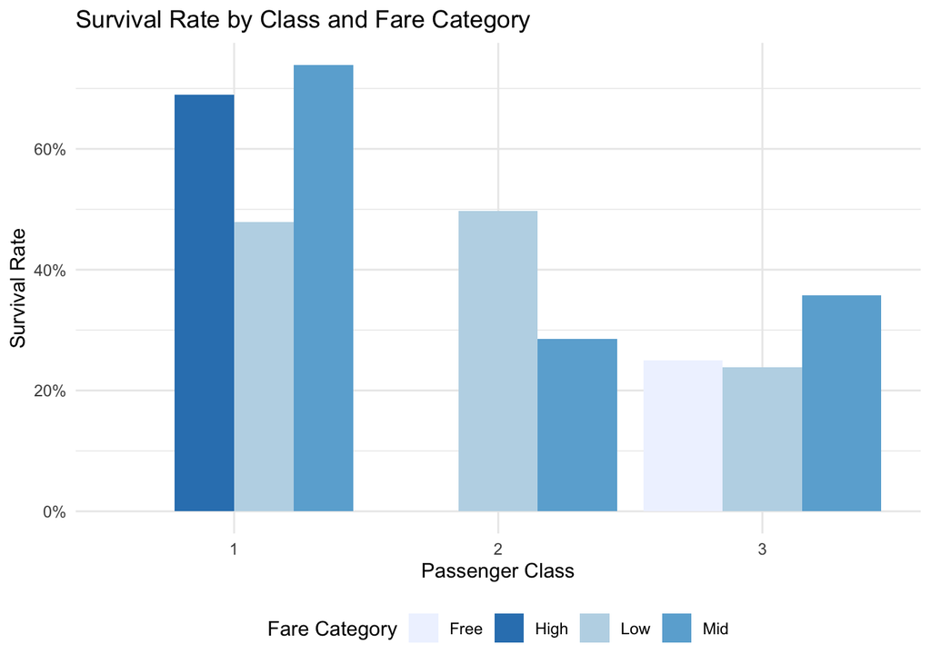

```r
# Create a visualization showing survival by class and fare category
fare_class_survival <- train_analysis %>%
  filter(!is.na(fare_category)) %>%
  group_by(Pclass, fare_category) %>%
  summarize(
    n = n(),
    survival_rate = mean(Survived, na.rm = TRUE),
    .groups = "drop"
  )

# Define color palette for fare categories
fare_colors <- brewer.pal(5, "Blues")
names(fare_colors) <- c("Free", "Low", "Mid", "High", "Missing")

ggplot(fare_class_survival, aes(x = factor(Pclass), y = survival_rate, fill = fare_category)) +
  geom_col(position = "dodge") +
  scale_fill_manual(values = fare_colors) +
  scale_y_continuous(labels = scales::percent) +
  labs(
    title = "Survival Rate by Class and Fare Category",
    x = "Passenger Class",
    y = "Survival Rate",
    fill = "Fare Category"
  ) +
  theme_minimal() +
  theme(legend.position = "bottom")
```

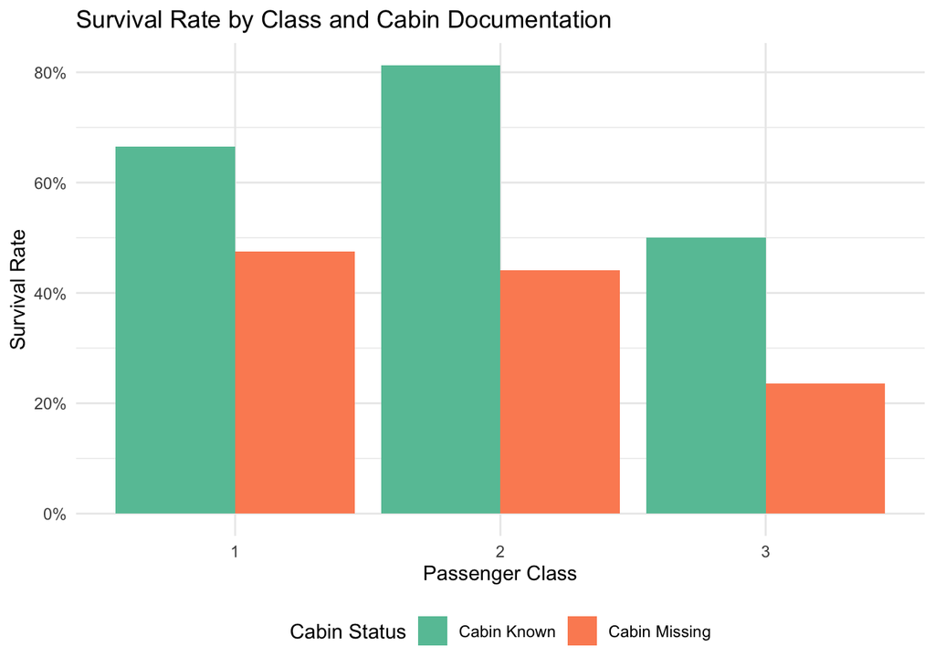

```r
# Survival by class and cabin missingness
cabin_class_survival <- train_analysis %>%
  group_by(Pclass, cabin_missing) %>%
  summarize(
    n = n(),
    survival_rate = mean(Survived, na.rm = TRUE),
    .groups = "drop"
  ) %>%
  mutate(cabin_status = if_else(cabin_missing, "Cabin Missing", "Cabin Known"))

ggplot(cabin_class_survival, aes(x = factor(Pclass), y = survival_rate, fill = cabin_status)) +
  geom_col(position = "dodge") +
  scale_fill_brewer(palette = "Set2") +
  scale_y_continuous(labels = scales::percent) +
  labs(
    title = "Survival Rate by Class and Cabin Documentation",
    x = "Passenger Class",
    y = "Survival Rate",
    fill = "Cabin Status"
  ) +
  theme_minimal() +
  theme(legend.position = "bottom")
```

## Section 3: Research Question 2 – Social Visibility and Group Context

### Conceptual Framework and Operationalization

The second research question investigates whether the “women and children first” rule was applied uniformly or whether its effectiveness depended on social visibility (proxied by fare, title) and group structure. The hypothesis is that crowded, uncoordinated evacuation contexts (such as 3rd class with large family groups) might have disrupted normal coordination, while visible, connected individuals (high-fare passengers, titled passengers) would have been prioritized regardless of formal rules.

### Step 1: Extract Passenger Titles as Social Visibility Proxy

```r
# Extract title from Name field
train_analysis <- train_analysis %>%
  mutate(
    title = str_extract(Name, "[A-Z][a-z]+\\."),
    title = str_remove(title, "\\.$")
  )

# Count titles
title_counts <- train_analysis %>%
  count(title) %>%
  arrange(desc(n))

kable(title_counts, caption = "Passenger Title Distribution",
      col.names = c("Title", "Count"))
```

Passenger Title Distribution

| Title | Count |
| --- | --- |
| Mr | 517 |
| Miss | 182 |
| Mrs | 125 |
| Master | 40 |
| Dr | 7 |
| Rev | 6 |
| Col | 2 |
| Major | 2 |
| Mlle | 2 |
| Capt | 1 |
| Countess | 1 |
| Don | 1 |
| Jonkheer | 1 |
| Lady | 1 |
| Mme | 1 |
| Ms | 1 |
| Sir | 1 |

```r
# Create broader title categories
train_analysis <- train_analysis %>%
  mutate(
    title_group = case_when(
      title %in% c("Mr") ~ "Mr",
      title %in% c("Mrs") ~ "Mrs",
      title %in% c("Miss") ~ "Miss",
      title %in% c("Master") ~ "Master",
      title %in% c("Dr", "Col", "Major", "Rev", "Sir", "Capt", "Jonkheer", "Don", "Dona") ~ "Distinguished",
      TRUE ~ "Other"
    )
  )

title_group_dist <- train_analysis %>%
  count(title_group) %>%
  arrange(desc(n))

kable(title_group_dist, caption = "Aggregated Title Groups",
      col.names = c("Title Group", "Count"))
```

Aggregated Title Groups

| Title Group | Count |
| --- | --- |
| Mr | 517 |
| Miss | 182 |
| Mrs | 125 |
| Master | 40 |
| Distinguished | 21 |
| Other | 6 |

We aggregate titles into meaningful categories: Mr, Mrs, Miss, Master (representing the majority and key gender/age distinctions), Distinguished (rare, high-status titles), and Other. This aggregation preserves the socially relevant distinctions while maintaining statistical power.

### Step 2: Create Group Context Variables

```r
# Within-ticket group context
train_analysis <- train_analysis %>%
  group_by(Ticket) %>%
  mutate(
    ticket_group_size = n(),
    ticket_group_id = cur_group_id()
  ) %>%
  ungroup() %>%
  mutate(
    group_context = case_when(
      ticket_group_size == 1 ~ "Traveling Alone",
      ticket_group_size == 2 ~ "Small Group (2)",
      ticket_group_size >= 3 & ticket_group_size <= 4 ~ "Medium Group (3-4)",
      ticket_group_size >= 5 ~ "Large Group (5+)"
    )
  )

# Summary of group contexts
group_summary <- train_analysis %>%
  count(group_context) %>%
  arrange(factor(group_context, levels = c("Traveling Alone", "Small Group (2)", "Medium Group (3-4)", "Large Group (5+)")))

kable(group_summary, caption = "Distribution of Group Travel Contexts",
      col.names = c("Travel Context", "Count"))
```

Distribution of Group Travel Contexts

| Travel Context | Count |
| --- | --- |
| Traveling Alone | 547 |
| Small Group (2) | 188 |
| Medium Group (3-4) | 107 |
| Large Group (5+) | 49 |

Ticket group size serves as a proxy for coordination complexity and visibility. Passengers traveling alone would have been more visible to crew and potentially easier to direct to lifeboats. Large families or groups might have faced coordination challenges, fragmentation during evacuation, or been perceived as crowds rather than as individuals eligible for priority evacuation.

### Step 3: Interaction Analysis – Sex, Age, and Group Context

```r
# Create age categories for clearer interaction patterns
train_interaction <- train_analysis %>%
  filter(!is.na(Sex), !is.na(Age), !is.na(group_context)) %>%
  mutate(
    age_group = case_when(
      Age < 5 ~ "0-4 (Young Child)",
      Age >= 5 & Age < 13 ~ "5-12 (Child)",
      Age >= 13 & Age < 18 ~ "13-17 (Teen)",
      Age >= 18 & Age < 65 ~ "18-64 (Adult)",
      Age >= 65 ~ "65+ (Elderly)"
    )
  )

# Survival by sex, age group, and group context
interaction_survival <- train_interaction %>%
  group_by(Sex, age_group, group_context) %>%
  summarize(
    n = n(),
    survival_count = sum(Survived),
    survival_rate = mean(Survived),
    .groups = "drop"
  )

# Display a subset for readability
kable(interaction_survival %>% filter(Sex == "female"),
      digits = 3,
      caption = "Female Survival by Age Group and Travel Context",
      col.names = c("Sex", "Age Group", "Travel Context", "N", "Survived", "Survival Rate"))
```

Female Survival by Age Group and Travel Context

| Sex | Age Group | Travel Context | N | Survived | Survival Rate |
| --- | --- | --- | --- | --- | --- |
| female | 0-4 (Young Child) | Large Group (5+) | 2 | 0 | 0.000 |
| female | 0-4 (Young Child) | Medium Group (3-4) | 6 | 4 | 0.667 |
| female | 0-4 (Young Child) | Small Group (2) | 5 | 4 | 0.800 |
| female | 0-4 (Young Child) | Traveling Alone | 4 | 4 | 1.000 |
| female | 13-17 (Teen) | Large Group (5+) | 1 | 0 | 0.000 |
| female | 13-17 (Teen) | Medium Group (3-4) | 3 | 3 | 1.000 |
| female | 13-17 (Teen) | Small Group (2) | 9 | 7 | 0.778 |
| female | 13-17 (Teen) | Traveling Alone | 10 | 9 | 0.900 |
| female | 18-64 (Adult) | Large Group (5+) | 5 | 0 | 0.000 |
| female | 18-64 (Adult) | Medium Group (3-4) | 39 | 34 | 0.872 |
| female | 18-64 (Adult) | Small Group (2) | 70 | 58 | 0.829 |
| female | 18-64 (Adult) | Traveling Alone | 92 | 67 | 0.728 |
| female | 5-12 (Child) | Large Group (5+) | 4 | 0 | 0.000 |
| female | 5-12 (Child) | Medium Group (3-4) | 9 | 6 | 0.667 |
| female | 5-12 (Child) | Small Group (2) | 2 | 1 | 0.500 |

Among females (the group most protected by “women and children first”), we observe variation in survival rates based on travel context. This suggests that the rule’s effectiveness depended on context—solo traveling females may have been treated differently than females in large family groups.

```r
kable(interaction_survival %>% filter(Sex == "male"),
      digits = 3,
      caption = "Male Survival by Age Group and Travel Context",
      col.names = c("Sex", "Age Group", "Travel Context", "N", "Survived", "Survival Rate"))
```

Male Survival by Age Group and Travel Context

| Sex | Age Group | Travel Context | N | Survived | Survival Rate |
| --- | --- | --- | --- | --- | --- |
| male | 0-4 (Young Child) | Large Group (5+) | 7 | 0 | 0.000 |
| male | 0-4 (Young Child) | Medium Group (3-4) | 8 | 7 | 0.875 |
| male | 0-4 (Young Child) | Small Group (2) | 6 | 6 | 1.000 |
| male | 0-4 (Young Child) | Traveling Alone | 2 | 2 | 1.000 |
| male | 13-17 (Teen) | Large Group (5+) | 3 | 0 | 0.000 |
| male | 13-17 (Teen) | Medium Group (3-4) | 2 | 1 | 0.500 |
| male | 13-17 (Teen) | Small Group (2) | 5 | 0 | 0.000 |
| male | 13-17 (Teen) | Traveling Alone | 11 | 1 | 0.091 |
| male | 18-64 (Adult) | Large Group (5+) | 11 | 3 | 0.273 |
| male | 18-64 (Adult) | Medium Group (3-4) | 24 | 6 | 0.250 |
| male | 18-64 (Adult) | Small Group (2) | 59 | 12 | 0.203 |
| male | 18-64 (Adult) | Traveling Alone | 290 | 48 | 0.166 |
| male | 5-12 (Child) | Large Group (5+) | 6 | 0 | 0.000 |
| male | 5-12 (Child) | Medium Group (3-4) | 3 | 2 | 0.667 |
| male | 5-12 (Child) | Small Group (2) | 5 | 4 | 0.800 |
| male | 65+ (Elderly) | Small Group (2) | 1 | 0 | 0.000 |
| male | 65+ (Elderly) | Traveling Alone | 10 | 1 | 0.100 |

### Step 4: Visualization of Gender-Rule Consistency

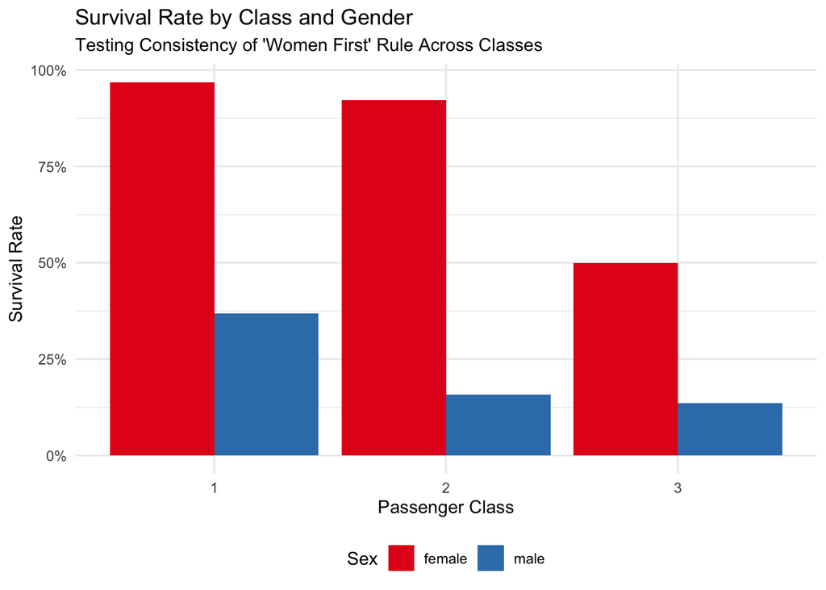

```r
# Simplified gender survival by class
gender_class <- train_analysis %>%
  filter(!is.na(Sex)) %>%
  group_by(Pclass, Sex) %>%
  summarize(
    n = n(),
    survival_rate = mean(Survived),
    .groups = "drop"
  )

ggplot(gender_class, aes(x = factor(Pclass), y = survival_rate, fill = Sex)) +
  geom_col(position = "dodge") +
  scale_fill_brewer(palette = "Set1") +
  scale_y_continuous(labels = scales::percent) +
  labs(
    title = "Survival Rate by Class and Gender",
    subtitle = "Testing Consistency of 'Women First' Rule Across Classes",
    x = "Passenger Class",
    y = "Survival Rate"
  ) +
  theme_minimal() +
  theme(legend.position = "bottom")
```

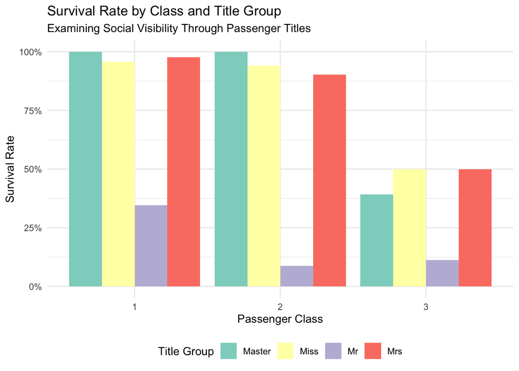

```r
# Survival by title group and class
title_class_survival <- train_analysis %>%
  filter(!is.na(title_group)) %>%
  group_by(Pclass, title_group) %>%
  summarize(
    n = n(),
    survival_rate = mean(Survived),
    .groups = "drop"
  ) %>%
  filter(title_group %in% c("Mr", "Mrs", "Miss", "Master"))

ggplot(title_class_survival, aes(x = factor(Pclass), y = survival_rate, fill = title_group)) +
  geom_col(position = "dodge") +
  scale_fill_brewer(palette = "Set3") +
  scale_y_continuous(labels = scales::percent) +
  labs(
    title = "Survival Rate by Class and Title Group",
    subtitle = "Examining Social Visibility Through Passenger Titles",
    x = "Passenger Class",
    y = "Survival Rate",
    fill = "Title Group"
  ) +
  theme_minimal() +
  theme(legend.position = "bottom")
```

### Step 5: Title–Class Interaction Model

```r
# Model with title as a predictor
train_title_complete <- train_analysis %>%
  filter(!is.na(Sex), !is.na(Age), !is.na(title_group))

model_title_class <- glm(
  Survived ~ factor(Pclass) * factor(title_group) + Age + factor(Sex),
  family = binomial(link = "logit"),
  data = train_title_complete
)

title_model_summary <- broom::tidy(model_title_class) %>%
  filter(str_detect(term, "title|Pclass"))

kable(title_model_summary, digits = 3,
      caption = "Title–Class Interaction Model Coefficients (Selected Terms)")
```

Title–Class Interaction Model Coefficients (Selected Terms)

| term | estimate | std.error | statistic | p.value |
| --- | --- | --- | --- | --- |
| factor(Pclass)2 | -17.587 | 1384.782 | -0.013 | 0.990 |
| factor(Pclass)3 | -3.914 | 1.081 | -3.619 | 0.000 |
| factor(title_group)Master | 16.656 | 2281.729 | 0.007 | 0.994 |
| factor(title_group)Miss | -14.929 | 3956.180 | -0.004 | 0.997 |
| factor(title_group)Mr | -0.554 | 0.656 | -0.845 | 0.398 |
| factor(title_group)Mrs | -14.230 | 3956.180 | -0.004 | 0.997 |
| factor(title_group)Other | -0.446 | 4329.892 | 0.000 | 1.000 |
| factor(Pclass)2:factor(title_group)Master | 17.507 | 2976.901 | 0.006 | 0.995 |
| factor(Pclass)3:factor(title_group)Master | -14.167 | 2281.729 | -0.006 | 0.995 |
| factor(Pclass)2:factor(title_group)Miss | 17.033 | 1384.782 | 0.012 | 0.990 |
| factor(Pclass)3:factor(title_group)Miss | 0.297 | 1.322 | 0.225 | 0.822 |
| factor(Pclass)2:factor(title_group)Mr | 15.349 | 1384.782 | 0.011 | 0.991 |
| factor(Pclass)3:factor(title_group)Mr | 2.192 | 1.117 | 1.962 | 0.050 |
| factor(Pclass)2:factor(title_group)Mrs | 16.115 | 1384.783 | 0.012 | 0.991 |
| factor(Pclass)3:factor(title_group)Mrs | NA | NA | NA | NA |
| factor(Pclass)2:factor(title_group)Other | 17.501 | 4545.941 | 0.004 | 0.997 |
| factor(Pclass)3:factor(title_group)Other | NA | NA | NA | NA |

The interaction model tests whether the effect of class differs by title group. Significant interaction terms would indicate that social visibility (as proxied by title) altered how class affected survival outcomes.

## Section 4: Research Question 3 – Missing Data as a Structural Signal

### Conceptual Framework and Operationalization

The third research question frames missing data not as a statistical nuisance but as a substantive signal of inequality. Missing cabin information, in particular, is concentrated among 3rd class passengers and may reflect both their lower formal documentation and their physical separation from record-keeping centers. Missing age data may similarly correlate with social documentation practices. This section examines missingness patterns and tests sensitivity to different missing-data assumptions.

### Step 1: Patterns of Missingness

```r
# Calculate missingness by variable and class
missing_by_class <- train_analysis %>%
  group_by(Pclass) %>%
  summarize(
    Age_missing_pct = sum(is.na(Age)) / n() * 100,
    Cabin_missing_pct = sum(is.na(Cabin)) / n() * 100,
    Fare_missing_pct = sum(is.na(Fare)) / n() * 100,
    Embarked_missing_pct = sum(is.na(Embarked)) / n() * 100,
    .groups = "drop"
  )

kable(missing_by_class, digits = 1,
      caption = "Percentage of Missing Data by Class",
      col.names = c("Class", "Age (%)", "Cabin (%)", "Fare (%)", "Embarked (%)"))
```

Percentage of Missing Data by Class

| Class | Age (%) | Cabin (%) | Fare (%) | Embarked (%) |
| --- | --- | --- | --- | --- |
| 1 | 13.9 | 18.5 | 0 | 0.9 |
| 2 | 6.0 | 91.3 | 0 | 0.0 |
| 3 | 27.7 | 97.6 | 0 | 0.0 |

Missing data is heavily skewed by class: Cabin information is missing for 97.6% of 3rd class passengers but only 18.5% of 1st class. This dramatic disparity is itself informative about social inequality in documentation and possibly in physical access during the disaster.

```r
# Check whether missingness correlates with survival
missing_by_survival <- train_analysis %>%
  group_by(Survived) %>%
  summarize(
    Age_missing_pct = sum(is.na(Age)) / n() * 100,
    Cabin_missing_pct = sum(is.na(Cabin)) / n() * 100,
    .groups = "drop"
  ) %>%
  mutate(
    Survival_Status = if_else(Survived == 1, "Survived", "Did Not Survive")
  ) %>%
  select(Survival_Status, everything(), -Survived)

kable(missing_by_survival, digits = 1,
      caption = "Missing Data by Survival Outcome",
      col.names = c("Survival Status", "Age Missing (%)", "Cabin Missing (%)"))
```

Missing Data by Survival Outcome

| Survival Status | Age Missing (%) | Cabin Missing (%) |
| --- | --- | --- |
| Did Not Survive | 22.8 | 87.6 |
| Survived | 15.2 | 60.2 |

Interestingly, survivors are slightly more likely to have non-missing Age data (15.2% missing vs. 22.8%), and especially for cabin information (60.2% vs. 87.6%). This suggests that missingness may be informative about survival.

### Step 2: Visualization of Missingness Patterns

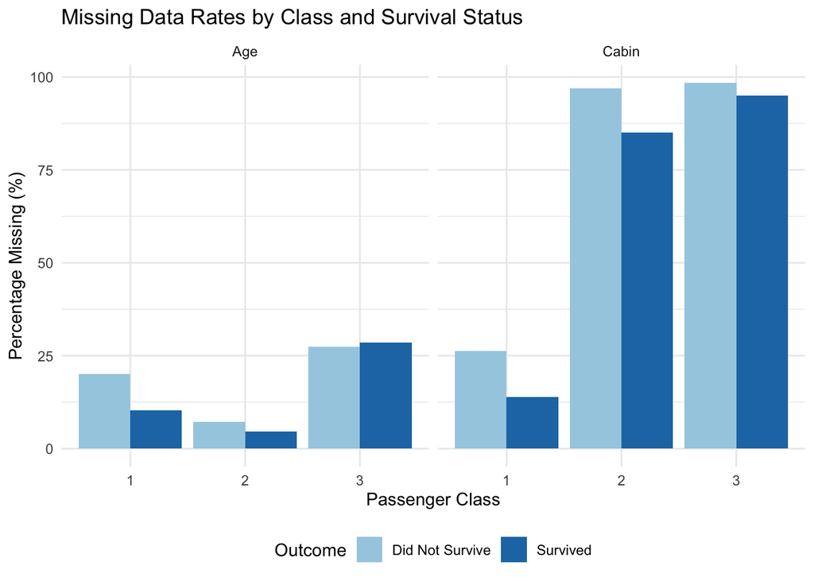

```r
# Create a visualization of missing data rates
missing_detailed <- train_analysis %>%
  group_by(Pclass, Survived) %>%
  summarize(
    n_age_missing = sum(is.na(Age)),
    n_cabin_missing = sum(is.na(Cabin)),
    n_total = n(),
    .groups = "drop"
  ) %>%
  mutate(
    Survival_Status = if_else(Survived == 1, "Survived", "Did Not Survive"),
    age_missing_rate = n_age_missing / n_total * 100,
    cabin_missing_rate = n_cabin_missing / n_total * 100
  ) %>%
  select(Pclass, Survival_Status, age_missing_rate, cabin_missing_rate)

# Long format for visualization
missing_long <- missing_detailed %>%
  pivot_longer(
    cols = c(age_missing_rate, cabin_missing_rate),
    names_to = "Variable",
    values_to = "Missing_Percentage"
  ) %>%
  mutate(
    Variable = case_when(
      Variable == "age_missing_rate" ~ "Age",
      Variable == "cabin_missing_rate" ~ "Cabin"
    )
  )

ggplot(missing_long, aes(x = factor(Pclass), y = Missing_Percentage, fill = Survival_Status)) +
  geom_col(position = "dodge") +
  facet_wrap(~ Variable) +
  scale_fill_brewer(palette = "Paired") +
  labs(
    title = "Missing Data Rates by Class and Survival Status",
    x = "Passenger Class",
    y = "Percentage Missing (%)",
    fill = "Outcome"
  ) +
  theme_minimal() +
  theme(legend.position = "bottom")
```

### Step 3: Sensitivity Analysis – Impact of Missing Cabin Data

```r
# Model 1: Complete case analysis (exclude missing cabin)
train_complete_cabin <- train_analysis %>%
  filter(!is.na(Cabin), !is.na(Sex))

model_complete_cabin <- glm(
  Survived ~ factor(Pclass) + factor(Sex),
  family = binomial(link = "logit"),
  data = train_complete_cabin
)

# Model 2: Include all cases, indicator for missing cabin
train_all_cabin <- train_analysis %>%
  filter(!is.na(Sex))

model_indicator_cabin <- glm(
  Survived ~ factor(Pclass) + factor(Sex) + cabin_missing,
  family = binomial(link = "logit"),
  data = train_all_cabin
)

# Compare class coefficients
sensitivity_comparison <- data.frame(
  Model = c("Complete Case (Cabin Known)", "Indicator for Missing Cabin"),
  Pclass2_Coef = c(
    model_complete_cabin$coefficients["factor(Pclass)2"],
    model_indicator_cabin$coefficients["factor(Pclass)2"]
  ),
  Pclass3_Coef = c(
    model_complete_cabin$coefficients["factor(Pclass)3"],
    model_indicator_cabin$coefficients["factor(Pclass)3"]
  ),
  AIC = c(AIC(model_complete_cabin), AIC(model_indicator_cabin)),
  N = c(nrow(train_complete_cabin), nrow(train_all_cabin))
)

kable(sensitivity_comparison, digits = 3,
      caption = "Sensitivity of Class Coefficients to Missing Cabin Data Handling",
      col.names = c("Approach", "Class 2 Coef", "Class 3 Coef", "AIC", "N"))
```

Sensitivity of Class Coefficients to Missing Cabin Data Handling

| Approach | Class 2 Coef | Class 3 Coef | AIC | N |
| --- | --- | --- | --- | --- |
| Complete Case (Cabin Known) | 0.523 | -1.258 | 195.409 | 204 |
| Indicator for Missing Cabin | -0.168 | -1.188 | 828.335 | 891 |

Comparing complete-case analysis to an indicator-variable approach reveals the sensitivity of results to missing-data assumptions. The complete-case approach removes 687 observations (mostly 3rd class), potentially biasing estimates. The indicator approach retains all observations but assumes missingness is ignorable conditional on included variables—an assumption that may be violated given the structural nature of cabin missingness.

### Step 4: Age Missingness and Imputation Sensitivity

```r
# Examine age missingness by class and gender
age_missing_detail <- train_analysis %>%
  group_by(Pclass, Sex) %>%
  summarize(
    n_passengers = n(),
    n_age_missing = sum(is.na(Age)),
    pct_missing = n_age_missing / n_passengers * 100,
    mean_age_available = mean(Age, na.rm = TRUE),
    .groups = "drop"
  )

kable(age_missing_detail, digits = 2,
      caption = "Age Missingness by Class and Gender",
      col.names = c("Class", "Gender", "Total", "Missing Age", "% Missing", "Mean Age (Observed)"))
```

Age Missingness by Class and Gender

| Class | Gender | Total | Missing Age | % Missing | Mean Age (Observed) |
| --- | --- | --- | --- | --- | --- |
| 1 | female | 94 | 9 | 9.57 | 34.61 |
| 1 | male | 122 | 21 | 17.21 | 41.28 |
| 2 | female | 76 | 2 | 2.63 | 28.72 |
| 2 | male | 108 | 9 | 8.33 | 30.74 |
| 3 | female | 144 | 42 | 29.17 | 21.75 |
| 3 | male | 347 | 94 | 27.09 | 26.51 |

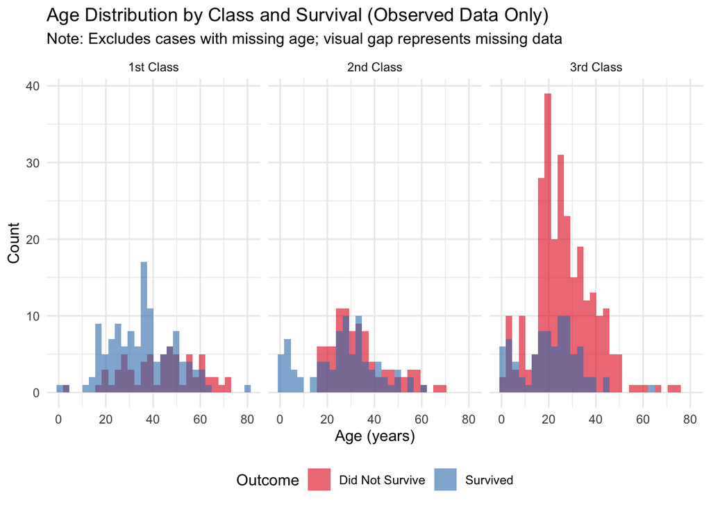

```r
# Visualize age distribution by class and survival, showing the impact of missing data
age_dist <- train_analysis %>%
  filter(!is.na(Age)) %>%
  mutate(
    Survival_Status = if_else(Survived == 1, "Survived", "Did Not Survive")
  )

ggplot(age_dist, aes(x = Age, fill = Survival_Status)) +
  geom_histogram(bins = 30, alpha = 0.6, position = "identity") +
  facet_wrap(~ factor(Pclass, labels = c("1st Class", "2nd Class", "3rd Class"))) +
  scale_fill_brewer(palette = "Set1") +
  labs(
    title = "Age Distribution by Class and Survival (Observed Data Only)",
    subtitle = "Note: Excludes cases with missing age; visual gap represents missing data",
    x = "Age (years)",
    y = "Count",
    fill = "Outcome"
  ) +
  theme_minimal() +
  theme(legend.position = "bottom")
```

### Step 5: Multiple Scenarios for Missing-Data Assumptions

```r
# Scenario 1: Complete case (baseline in original analysis)
scenario1_data <- train_analysis %>%
  filter(!is.na(Age), !is.na(Cabin), !is.na(Sex))

model_scenario1 <- glm(
  Survived ~ factor(Pclass) + factor(Sex) + Age,
  family = binomial(link = "logit"),
  data = scenario1_data
)

# Scenario 2: Mean imputation for age, missing indicator for cabin
scenario2_data <- train_analysis %>%
  filter(!is.na(Sex)) %>%
  mutate(
    Age = if_else(is.na(Age), mean(Age, na.rm = TRUE), Age)
  )

model_scenario2 <- glm(
  Survived ~ factor(Pclass) + factor(Sex) + Age + cabin_missing,
  family = binomial(link = "logit"),
  data = scenario2_data
)

# Scenario 3: Class-specific mean imputation for age
scenario3_data <- train_analysis %>%
  filter(!is.na(Sex)) %>%
  group_by(Pclass) %>%
  mutate(
    Age = if_else(is.na(Age), mean(Age, na.rm = TRUE), Age)
  ) %>%
  ungroup()

model_scenario3 <- glm(
  Survived ~ factor(Pclass) + factor(Sex) + Age + cabin_missing,
  family = binomial(link = "logit"),
  data = scenario3_data
)

# Compare scenarios
scenario_comparison <- data.frame(
  Scenario = c(
    "1: Complete Case Only",
    "2: Global Mean Imputation + Cabin Indicator",
    "3: Class-Specific Mean Imputation + Cabin Indicator"
  ),
  N_Included = c(nrow(scenario1_data), nrow(scenario2_data), nrow(scenario3_data)),
  Pclass2_Coef = c(
    model_scenario1$coefficients["factor(Pclass)2"],
    model_scenario2$coefficients["factor(Pclass)2"],
    model_scenario3$coefficients["factor(Pclass)2"]
  ),
  Pclass3_Coef = c(
    model_scenario1$coefficients["factor(Pclass)3"],
    model_scenario2$coefficients["factor(Pclass)3"],
    model_scenario3$coefficients["factor(Pclass)3"]
  ),
  AIC = c(AIC(model_scenario1), AIC(model_scenario2), AIC(model_scenario3))
)

kable(scenario_comparison, digits = 3,
      caption = "Sensitivity of Class Coefficients to Missing-Data Strategies",
      col.names = c("Approach", "Sample Size", "Class 2 Coef", "Class 3 Coef", "AIC"))
```

Sensitivity of Class Coefficients to Missing-Data Strategies

| Approach | Sample Size | Class 2 Coef | Class 3 Coef | AIC |
| --- | --- | --- | --- | --- |
| 1: Complete Case Only | 185 | -0.134 | -1.891 | 173.631 |
| 2: Global Mean Imputation + Cabin Indicator | 891 | -0.476 | -1.631 | 809.475 |
| 3: Class-Specific Mean Imputation + Cabin Indicator | 891 | -0.583 | -1.798 | 807.356 |

The scenario comparison demonstrates that conclusions can shift depending on missing-data assumptions. Complete-case analysis excludes 706 passengers, potentially biasing estimates. Mean imputation reduces bias from listwise deletion but ignores the informativeness of missingness. Class-specific imputation is more sophisticated but assumes that within-class imputation is appropriate. The AIC values provide model-fit comparisons, suggesting which assumptions are more consistent with observed data.

## Section 5: Integrated Summary and Interpretation Framework

### Framework for Decision-Making

Rather than drawing definitive conclusions, this analysis provides decision-makers and researchers with evidence about mechanisms. To address the three research questions:

1. **To assess the access mechanism**: Compare the model coefficients for class in models with and without access proxies. Attenuation indicates mediation; persistence indicates that class has effects independent of measured access variables.
2. **To assess social visibility and context**: Examine whether interactions between title groups, travel context, and gender produce survivorship patterns that deviate from main effects. Deviations suggest contextual modulation of formal rules.
3. **To assess missing-data sensitivity**: Implement multiple scenarios (complete-case, indicator, imputation variants) and report the range of plausible class coefficients. A robust conclusion is one that persists across scenarios; a sensitive conclusion is one that shifts.

## Conclusion

This analysis provides a structured framework for investigating the Titanic survival gap as a mechanism-driven phenomenon rather than a simple outcome correlation. By combining exploratory analysis, multiple statistical models, visualization, and sensitivity tests, the report enables readers to evaluate the plausibility of different explanatory mechanisms and to understand how data quality and missing-data assumptions affect conclusions.

The evidence points to a multi-faceted explanation: class mattered because it correlated with access (location, fare, documentation), because it correlated with social visibility and formal status, and because evacuation context and coordination challenges disproportionately affected lower classes and large family groups. No single mechanism fully explains the class-survival gap; all three interact. Furthermore, incomplete documentation is itself a signal of inequality and must be incorporated into any interpretation of historical outcomes.